# Estimating Price Index using Web Scrapped Data: Daily Laptop Price Change from Amazon.com

Harold Gomes

2019-12-15

Abstract

This project investigates how to produce price change indexes from the web data in a real-time collection, using web scrapping method. In specific, it creates a pipeline within the limited scope and time that includes web scrapping data of 100-best laptops from Amazon.com using HTML method, formatting data for analysis, computing daily price change indexes using Price Theory formulas—Laspeyres, Paasche, Geo-means, Fisher, Tornqvist, and Unweighted—and finally visually displaying the index time series to the stakeholders in a real-time employing the Shiny App with 3 types of regressions, and a JavaScript style HTML object. In addition to daily price change index, 1-month price change index is also calculated for November 2019, so that the Amazon laptop price index could be compared with the BLS produced EE01 Index. EE01 is a Basic Item Strata, “Personal computers and peripheral equipment”. Comparison-results are not similar, but potential justifications have been proposed for this difference. Time series methodology is also implemented to generate statistical inference from the laptop index time series.

```r
library(knitr)
library(tidyverse)
library(tsbox)
library(forecast)
library(tseries)
#getwd()
load('2019-11-15_1.Rda')
load('data_index.Rda')
load('data_PC.Rda')
load('BLS_df.Rda')
load('T_summary.Rda')
load('Monthly_IX.Rda')
```

# Importance and Motivation for this Study

The price indexes are important measures of economy, and indicators of well-being and stability for a nation. There are many types of indexes, such as, price index and financial index (stock market index). Price indexes include Consumer Price Index (CPI), Producer Price Index (PPI), Import-Export Price Index, etc., while financial indexes include Dow Jones Industrial Average Index and S&P 500 for stock market movements (private). Price or financial indexes are a way of summarizing the overall price (or financial) changes between two periods, base (previous) and current.

International Labour Organization (jointly with OECD, UNECE, Eurostat, and The World Bank) publishes “Consumer price index manual: Theory and practice” a standard manual (guidance) for nations to replicate a standard methodology for CPI. According to ILO, “A CPI measures the rate of price inflation as experienced and perceived by households in their role as consumers (ILO 2004).”

The Bureau of Labor Statistics (BLS) produces the official U.S. inflation rate, a monthly index, the Consumer Price Index (CPI). CPI is used to adjust the GDP, Social Security, Salary, Tax Return, and many important aspects of American lives.

“The Consumer Price Index (CPI) is a measure of the average change over time in the prices of consumer items—goods and services that people buy for day-today living. The CPI is a complex measure that combines economic theory with sampling and other statistical techniques and uses data from several surveys to produce a timely and precise measure of average price change for the consumption sector of the American economy (BLS 2018).”

The importance of CPI in everyday life motivated to design this study, i.e., to develop a framework and methodology to compute the percent-change price index from the web scrapped data. Although an index is a number but it is often represented as a percentage change (%) between 2 periods for better interpretability. Hence, throughout this paper, “price change” or “price index” would essentially refer to the same idea, percent-change (%) of price index between 2 periods.

# Consumer Price Index Methodology

CPI is a weighted-average of price change of consumer items over time. “A price index is a measure of the proportionate, or percentage, changes in a set of prices over time. A consumer price index (CPI) measures changes in the prices of goods and services that households consume (ILO 2004).” In other words, CPI measures the average change in prices that consumers pay for a basket of goods and services over time.

BLS estimates CPI based on a randomly selected items, i.e., probability sample of unique items. BLS implements a multistage area sample design that includes sample weights, adjustment factors, geographic stratification, clusters, and other characteristics of a larger survey sample design and collection features. Sample weights (expenditure) are used to transform each collected price quote into a population level estimates. Hence, CPI is a population level index, representing 94% of the U.S. population. Elementary (Basic) indexes are computed for each combination of an item stratum and index area (e.g., an Index is produced for Men’s Suit in NY Area) using Quote weight (Final Sample Weight). Finally, aggregation weight—extracted from another survey, Consumer Expenditure Survey—is used to combine the market basket proportions. That is, average the basic indexes into aggregate CPI indexes (e.g., all-items average NY or U.S. level Index). BLS employs data collectors who collects monthly data from different outlets across U.S., so it is a monthly Index. BLS also collects some prices using web scrapping methods from the websites, but these samples are *weighted* properly just like any other price-quotes. Web scrapping is just a *mode of collection*. It uses weighted Laspeyres or Geo-Means formula depending on an item strata to compute an elementary index from price quotes using expenditure weights not quantity (BLS 2018; ILO 2004). There are other index formulas in Price Theory.

# Developing Price Index Using Web Scrapping Methodology

## Defining Scope of this Project

The scope of this project is limited due to time constraints (slightly over 1 month). Hence a daily price change index is computed, not monthly. Additionally, price index for a very specific item is selected, such as Laptop, so that the same unique brand of laptops could be followed over time.

## Research Objectives

The research objectives for this study are as follows:

1. Develop percent-change price index from the web scrapped Amazon data.
2. Construct a pipeline to implement the methodology.
3. Construct a repeated step-process that could potentially serve as a prototype for production.
4. Compute daily price-change index based on Price Theory.
5. Innovate assumptions and decisions rules when traditional approach is insufficient.
6. Develop a Shiny App to display the index in real-time updates.
7. Implement Linear, LOESS and Spline (piecewise polynomial) regressions in Shiny App.
8. Compare Amazon index with BLS CPI index.
9. Use Times Series methodology for statistical inference about the laptop index series.

## Data Collection and Wrangling

Initially, market research was conducted to find a feasible website and items with extensive characteristics match, so that a unique item could be identified and joined easily. The Walmart website was assessed in order to produce Walmart food index using API (Walmart 2019). However, Walmart stopped its API services and many food prices on the website display “In-store purchase only” that made HTML web scraping not useful. Furthermore, a paint website (www.sherwin-williams.com) was also examined before finally selecting the 100 “Best Seller” laptops from Amazon.com for this project (Amazon 2019). There are few benefits for selecting this item. First, the unique product ID captures name and all the characteristics of a unique laptop. Tables 1 and 2 show the matched laptop names and data between 2 periods. Second, it provides the Number of Reviews that could potentially be used as a proxy for weight. Also, the path for HTML web scrapping is fairly stable. Once this selection is finalized for the study, few R scripts are developed so that the price could be downloaded daily. After data is downloaded based on HTML web scraping method, it goes through a data wrangling, cleaning and formatting process before the daily laptop data is saved in a local repository (Table 1 and 2).

```r
pop_ranked <- pop2 %>% arrange(., by_group = desc(Price))

kable(as_tibble(pop_ranked[c(1, 2, 3,10),3:6]), align='c', caption="Web scrapped Data from Amazon \n (sample after formatting)", booktabs = T)
```

Web scrapped Data from Amazon (sample after formatting)

| Rating | Count_Review | Price | Date |
| --- | --- | --- | --- |
| 4.1 | 94 | 2349.00 | 2019-11-15 |
| 4.1 | 94 | 1999.00 | 2019-11-15 |
| 4.4 | 130 | 1599.00 | 2019-11-15 |
| 4.2 | 449 | 1092.49 | 2019-11-15 |

```r
b <- pop_ranked[c(1, 2, 3,10),2] %>% as_tibble() %>% rename(., "Table 2: Product Name with Characteristics"=value)
b
```

| Table 2: Product Name with Characteristics |
| --- |
| New Apple MacBook Pro (15-inch, 16GB RAM, 512GB Storage) - Space Gray |
| New Apple MacBook Pro (15-inch, 16GB RAM, 256GB Storage) - Space Gray |
| New Apple MacBook Pro (13-inch, 8GB RAM, 256GB Storage) - Space Gray |
| Acer Predator Helios 300 Gaming Laptop PC, 15.6 inches Full HD 144Hz 3ms IPS Display, Intel i7-9750H, GTX 1660 Ti 6GB, 16GB DDR4, 256GB PCIe NVMe SSD, Backlit Keyboard, PH315-52-78VL |

## Price Theory and Index Formula

CPI is an approximate estimate of an economic concept known as the Cost of Living Index (COLI). Hence, there are many index formulas try to approximate this measure. “The theory of the COLI was first developed by Konus (1924) (ILO 2004).”

“Because the COLI is not directly observable, the CPI employs index number formulas that offer approximations to the measurement objective…. COLI for the current month is based on the answer to the following question: “What is the cost, at this month’s market prices, of achieving the standard of living actually attained in the base period?” (BLS 2018).”

There is a long history for CPI dating back to the 18th century. Laspeyres and Paasche indices were first proposed in the 1870s, which are still widely used today (ILO 2004). There exists a very large volume of literature on this subject. “Many different kinds of mathematical formulae have been proposed over the past two centuries (ILO 2004).” Each formula has an advantage and disadvantage, and what it can capture from the market basket (ILO 2004; BLS 2018). The Table 3 shows the Index formulas that are implemented in this study. No packages are used. The author of this study has coded these index formulas in R instead of using packages. This way, the author has the full control over computing the index from the data.

| Table 3: Index Name | Index Relative Formula | Index Name | Index Relative Formula |
| --- | --- | --- | --- |
| Laspeyres | $\displaystyle \frac{\sum_{i} p_i^{1}*q_i^{0}}{\sum_{i} p_i^{0}*q_i^{0}}$ | Paasche | $\displaystyle \frac{\sum_{i} p_i^{1}*q_i^{1}}{\sum_{i} p_i^{0}*q_i^{1}}$ |
| Geo-Means | $\displaystyle \prod_{i}(\frac{p_i^{1}}{p_i^{0}})^{s_i^{0}}$ | Tornqvist | $\displaystyle \prod_{i}(\frac{p_i^{1}}{p_i^{0}})^{(s_i^{0}+s_i^{1})/2}$ |
| Fisher | $\sqrt{Laspeyres*Paasche}$ | Unweighted | $\displaystyle \frac{\sum_{i} p_i^{1}}{\sum_{i} p_i^{0}}$ |

Percent Change (%) of any Index = (Index Relative - 1) * 100

*i = a unique item*

$\ p_i^{1}$ = *price of item i at current period 1* $\ p_i^{0}$ = *price of item i at base period 0*

$\ q_i^{1}$ = *quantity of item i at current period 1* $\ q_i^{0}$ = *quantity of item i at base period 0*

$\ s_i^{1}$ = *Expenditure share of item i at current period 1* $\ s_i^{0}$ = *Expenditure share of item i at base period 0*

## Methodological Innovations: Assumptions for Web Scrapped Data

Index formula requires “quantity” information ($q_0$) from the market basket. BLS uses the population level expenditure weight (Quote weight or Final Sample Weight). An index is considered unweighted when “weight” or “quantity” information is not incorporated. It is considered not very informative index as International Labour Organization articulates:

“Knowing that expenditures have increased by 5 percent is not very informative if we do not know how much of this change is attributable to changes in the prices of the goods and services, and how much to changes in the quantities purchased. The purpose of an index number is to decompose proportionate or percentage changes in value aggregates into their overall components of price and quantity change (ILO 2004).”

Hence, innovation requires some information about which laptops consumers buy. Two types of weight are constructed in this study: Proxy Weight, and Popularity Adjusted Proxy Weight.

*Proxy Weight:* The number of reviews for a unique laptop is treated as a proxy for quantity sold.

*Popularity Adjusted Proxy Weight:* The number of reviews are adjusted based on the popularity ratings (scale 1-5) using sample design principles; i.e., constructed adjustment and calibration factors, and multiplied the number of reviews by these factors (Valliant, Dever, and Kreuter 2013).

*Matched Sample:* Unique laptops that are matched between current and previous periods are used to calculate the “current” index (updated market basket).

## Implementation Process

A suite of R programs is developed by the author to execute these steps. These programs have functions and loops to automate the processes (Wickham and Grolemund 2017). The *Step1* R program is run daily for a month between 10 am to 4 pm. Multiple realized samples of Best 100 Laptops are collected from www.Amazon.com in each day. Once data is web scrapped, it is formatted and saved, ready for analysis. For index computation, 1 realized sample set is selected for each day and *Step2* R program is run. *Step 1* and *Step2* are the most important programs since they web scrape the data from Amazon and computes indexes using Price Theory formulas (Table 3).

*Step1_Webscrape_Laptop_Data.Rmd:* This program connects to Amazon website and scrapes the data of 100 best laptops using a loop. It uses various data wrangling techniques and string functions to manipulate the list object, and to make it ready for analysis. Finally, it saves the data object to be used in the subsequent steps.

*Step2_InnerJoin_Datasets_Compute_Index.Rmd:* This program matches the samples of laptops from any 2 periods (current and previous) and computes the percent change indexes based on the formulas of price theory. All formulas are coded with automation (no packages are used). It also computes the adjustment and calibration factors to incorporate the popularity ratings of laptops into the proxy weight. And finally it appends the daily price index into previously saved data.

*Step1.5_InnerJoin_Datasets_Compute_Index_BasePeriod.Rmd:* This program is replicated from *Step2* except it is customized to run only once for the base period when the index relative is set to 1 and percent change is 0. It saves the first dataset that is being appended daily by new percent change index.

*Step3_InnerJoin_Compute_Monthly_Change.Rmd:* This program is also replicated from *Step2* except it is customized to run and compute a 1-month percent change between October (base) and November (current). This monthly index enables to compare with BLS monthly index.

*Step4_Data_Visual.R:* This program produces various plots using ggplot2.

*Step5_Shiny_App.R:* This program is the Shiny App with advanced features that is currently on the public server for users (https://hlpgomes.shinyapps.io/priceindex/).

*Step6_dygraph.Rmd:* This program generates JavaScript style interactive plot, embedded into HTML. This could be shared with the clients to inspect the price index data interactively.

*Step7_StatisticalAnalysis.R:* This program conducts statistical analysis such as descriptive statistics, as well as inferential statistics with pairwise t-test and Wilcoxson signed rank test.

*Step8_CPI_Index_Laptop.R* This program pulls the data directly from the website, BLS public release repository, and computes the percent change index for EE01 Item Strata, “Personal computers and peripheral equipment.”.

*Step9_TimeSeries.R* This program implements Times Series methodology, such as autocorrelation function and decomposition function to the daily index dataset.

# Interesting Research Inquiry

In addition to computing the daily index, 3 research questions are formulated for Amazon laptop index.

### Do popular laptops have lower price change in average?

After assessing the index distribution for one month (Oct 30 to Nov 30), the exploratory observation confirms that the Popularity Adjusted Mean is slightly lower than the Proxy Weighted Mean of same index formula, i.e., more popular laptops have lower price change than less popular laptops in average. Hence the following hypotheses is formulated $H_a$: Popularity Adjusted Mean < Proxy Weighted Mean. Pairwise t-test and the non-parametric Wilcoxon signed rank test are both implemented to examine the hypotheses. Non-parametric test is emplyed due to small sample size, *n=31*.

### Does the overall laptop price-change index increase or decrease based on its past values?

Times Series methodology is employed to investigate this finding (Hyndman and Athanasopoulos 2018; Dettling 2015). Specifically, Autocorrelation and partial-autocorrelation functions are applied to the index times series.

Autocorrelation and partial-autocorrelation measure the relationship between a variable’s current value and its past values (lag). Significant lag values are used to develop forecasting model in order to predict current value based on the past values. `acf()` or `forecast::ggAcf()` function could be used.

### How does the *trend* look after adjusting for the effect of a day, such as Tuesday or Saturday (weekend)? Is the *trend* predictable?

To investigate this question, the trend needs to be examined after extracting the weekly seasonal component. That is, the laptop time series is decomposed into 3 components—Seasonality, Trend, Remainder—to investigate this finding. The additive or multiplicative decomposition could be employed. Whether the index time series is stationary could be examined using Dickey-Fuller Test, and white noise using Box-Ljung Test.

Additive decomposition: $y_t$ = $S_t$ + $T_t$ + $R_t$

Multiplicative decomposition: $y_t$ = $S_t$ * $T_t$ * $R_t$

# Results

Daily index is calculated for about a month, from October 30, 2019 to December 7, 2019. The base period is the start date October 30 when the index relative is 1 and the percent change is 0. For example, to compute the daily index for Oct 15, Amazon price dataset for Oct 15 is set as the **current period ($p_1$)** and Oct 14 as the **previous period** ($p_0$). **Step 2** R program is used for these calculations. The figures and tables below summarize the results.

## Daily Price Index (%)

*Figure 1* below tells an intuitive story of price index. Some laptop-prices decrease while others increase, and the net-result is a weighted average of *percent-chance price index*. A *bubble* is a matched laptop between the two periods, and the *bubble size* is the Proxy-weight for that laptop (Count_Review). The second figure of *Figure 1* displays the index series with magnification (y-axis) so series could be visually examined.

```r
### Produce Graph of Results
df0 <- data_index %>%
  filter(Date1 <= "2019-12-03") %>%     #"2019-11-30"
  select(Date1, Day1, L_IX, P_IX, G_IX, F_IX, T_IX, Unwgt_IX, IX_type) %>%
  rename(., Laspeyres=L_IX, Paasche=P_IX, Geo_means=G_IX, Fisher=F_IX, Tornqvist=T_IX, Unweighted=Unwgt_IX)

### Long Format ###
df <- gather(df0, Index, PercentChange, Laspeyres:Unweighted) %>%
  filter(., IX_type=="Proxy_wgt")
dt <- data_PC %>%
  rename(., Percent_Change = PriceChange_prct) %>%
  filter(Date1 <= "2019-12-03") #"2019-11-30"


h2 <- dt %>%
  ggplot(., aes(x = Date1, y=Percent_Change))

p1 <- h2 +
  geom_point(aes(size=Count_Review1), color="deepskyblue", alpha=0.3) + scale_size_area(max_size = 4) +
  geom_smooth(data=df, aes(x = Date1, y=PercentChange, group=Index, color=Index), method = "loess", se = FALSE) +
  scale_x_date(date_labels = "%b %d", breaks='7 day', minor_breaks = "1 day")

p2 <- h2 +
  geom_point(aes(size=Count_Review1), color="deepskyblue", alpha=0.3) + scale_size_area(max_size = 4) +
  geom_line(data=df, aes(x = Date1, y=PercentChange, group=Index, color=Index)) +
    geom_smooth(aes(group = Product_Name, color=Product_Name), method = "loess", se = FALSE, show.legend = FALSE) +
  geom_point(data=df, aes(x = Date1, y=PercentChange, group=Index, color=Index), alpha=0.7, size=1.3)  +
  scale_x_date(date_labels = "%b %d", breaks='7 day', minor_breaks = "1 day") + ylim(-4,4)


p7 <- h2 +
  geom_point(aes(size=Count_Review1), color="deepskyblue", alpha=0.3) + scale_size_area(max_size = 4) +
  geom_smooth(data=df, aes(x = Date1, y=PercentChange, group=Index), method = lm, formula = y ~ splines::bs(x, 12), se = FALSE, color="grey65") +
  geom_line(data=df, aes(x = Date1, y=PercentChange, group=Index, color=Index)) +
  geom_point(data=df, aes(x = Date1, y=PercentChange, group=Index, color=Index), alpha=0.7, size=1.3)  +
  scale_x_date(date_labels = "%b %d", breaks='7 day', minor_breaks = "1 day") + ylim(-4,4)


##### Theme ####
thm <-  theme(axis.title.x = element_text(face="bold", size=12),
              axis.title.y = element_text(face="bold", size=10),
              axis.text.x  = element_text(angle=0, vjust=0.5, size=10, face="bold"),
              axis.text.y  = element_text(hjust=0.5, size=10, face="bold"))
```

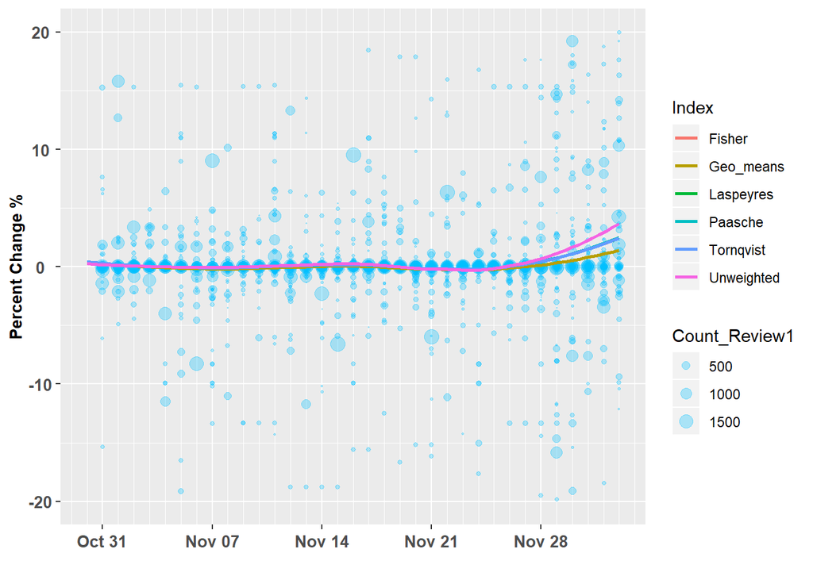

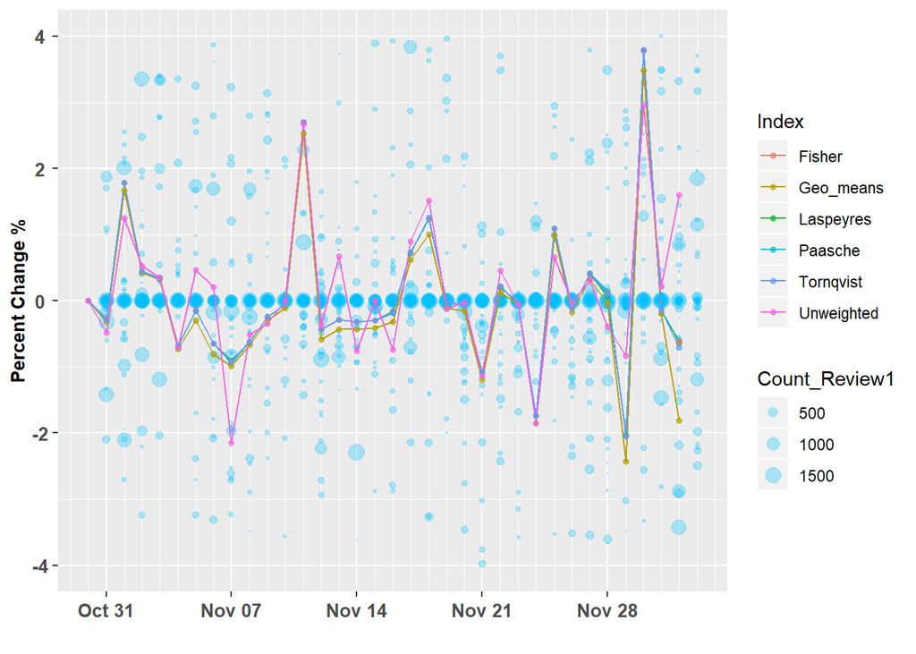

Daily Laptop Price Index

```r
################
## All Graphs ##
################

p1+ ylim(-20,20) + thm + xlab("") +  ylab("Percent Change %")
p2 + thm + xlab("") +  ylab("Percent Change %")
```

## Monthly BLS CPI Index (%) for EE01

The closest index to laptop item that BLS produces is EE01 Item Strata, “Personal computers and peripheral equipment”. It implies, this index has a mixed sample units of computers and other peripheral equipment. It is a monthly index and public data. *Figure 2* displays the BLS EE01 index from Feb 2016 to Nov 2019. It also has a spline regression: `y ~ splines::bs(x, degree=8)` to assess the trend.

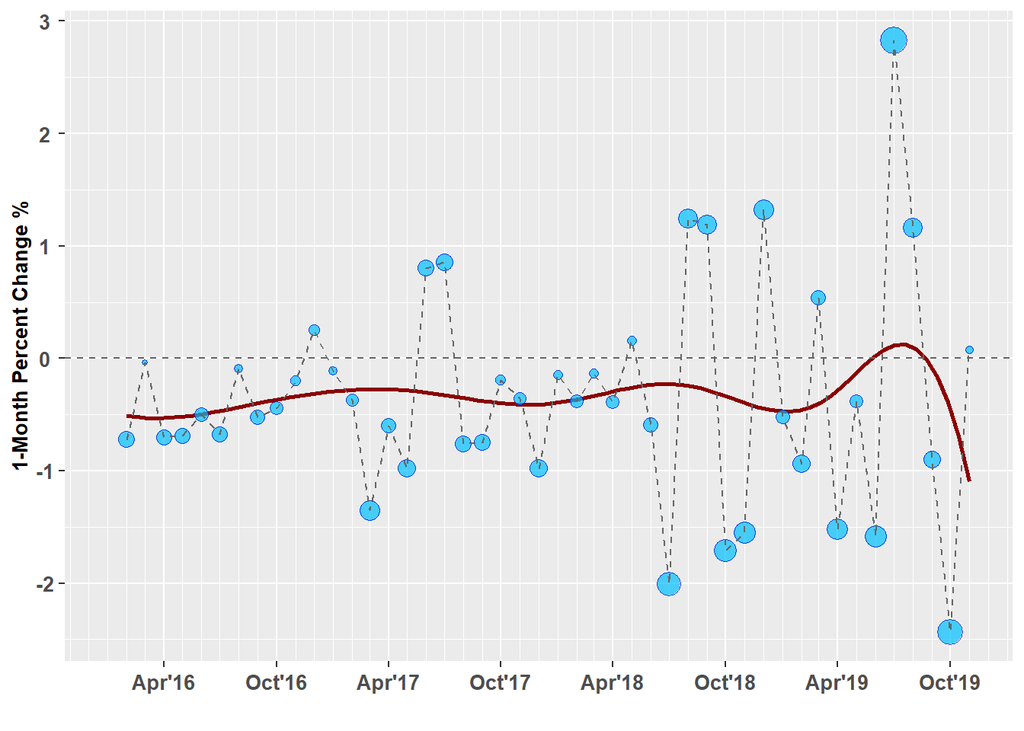

BLS EE01 1-Month Index

```r
p <- ggplot(BLS_df, aes(date, PC_1month))
p + scale_x_date(date_labels = "%b'%y", breaks='6 month', minor_breaks = "1 month") +
  geom_smooth(method = lm, formula = y ~ splines::bs(x, 8), se = FALSE, color="darkred") +
  geom_point(aes(size=abs(PC_1month)), color="blue3", fill="deepskyblue", alpha=0.7, shape = 21, show.legend = FALSE) +
  geom_hline(yintercept=0, linetype="dashed", color = "grey40") +
  geom_line(color="grey40", linetype = "dashed") + thm + xlab("") +  ylab("1-Month Percent Change %")
```

## Amazon and BLS Index Comparison: 1-month percent change (%)

The following *Tables 4 and 5* summarize the results of 1-month Amazon laptop percent-change index and 1-month BLS EE01. Laptop index is computed for 2 sets of dates: between Oct 30 *(previous)* and Nov 30 *(current)*; and between Oct 30 *(previous)* and Nov 26 *(current)* before Thanksgiving / Black Friday.

```r
kable(Monthly_IX %>% select(Index, PC_1Mo_Nov30_Oct30, PC_1Mo_Nov26_Oct30, IX_wgt_type) %>%
        rename(Nov30_Oct30=PC_1Mo_Nov30_Oct30, Nov26_Oct30=PC_1Mo_Nov26_Oct30), align='l', caption="1-Month Laptop Percent Change Index for 2 sets of Dates", booktabs = T)  ## works with knitr
```

1-Month Laptop Percent Change Index for 2 sets of Dates

| Index | Nov30_Oct30 | Nov26_Oct30 | IX_wgt_type |
| --- | --- | --- | --- |
| Laspeyres | -1.964 | -1.287 | Proxy_wgt |
| Laspeyres | -1.970 | -1.375 | Popularity_Adj_Proxy_wgt |
| Paasche | -1.479 | -1.416 | Proxy_wgt |
| Paasche | -1.535 | -1.541 | Popularity_Adj_Proxy_wgt |
| Geo_means | -2.171 | -1.445 | Proxy_wgt |
| Geo_means | -2.174 | -1.534 | Popularity_Adj_Proxy_wgt |
| Fisher | -1.722 | -1.351 | Proxy_wgt |
| Fisher | -1.752 | -1.458 | Popularity_Adj_Proxy_wgt |
| Tornqvist | -1.731 | -1.344 | Proxy_wgt |
| Tornqvist | -1.760 | -1.450 | Popularity_Adj_Proxy_wgt |
| Unweighted | -3.052 | -2.562 | Proxy_wgt |
| Unweighted | -3.052 | -2.562 | Popularity_Adj_Proxy_wgt |

```r
## BLS EE01 Index
BLS_df$PC_1month <- round(BLS_df$PC_1month, 3)

kable(BLS_df %>% mutate(., Index="Geo_means") %>%
        select(Index, PC_1month, date) %>%
        filter(., date >="2019-10-01") %>%
         arrange(desc(date)) %>%
        mutate(., date=format(as.Date(.$date), "%B %Y")),
      align='l', caption="1-Month BLS EE01 Percent Change Index", booktabs = T)
```

1-Month BLS EE01 Percent Change Index

| Index | PC_1month | date |
| --- | --- | --- |
| Geo_means | 0.077 | November 2019 |
| Geo_means | -2.434 | October 2019 |

## Do popular laptops have lower price change in average?

*Table 6* shows the exploratory findings (i.e., *difference in means*), and *Table 7* shows the results (p-values) of statistical tests. The *boxplot* below displays the entire index distribution and the mean (summary statistics of Table 6).

```r
####################
###    Table     ###
####################

df0_long3 <- data_index %>%
  filter(Date1 > "2019-10-30", Date1 <= "2019-11-30") %>%
  select(Date1, Day1, L_IX, P_IX, G_IX, F_IX, T_IX, Unwgt_IX, IX_type, n_matched) %>%
  rename(., Laspeyres=L_IX, Paasche=P_IX, Geo_means=G_IX, Fisher=F_IX, Tornqvist=T_IX, Unweighted=Unwgt_IX) %>%
  gather(., key=Index, value = Percent_Change, Laspeyres:Unweighted)

df3 <- df0_long3 %>% group_by(Index, IX_type) %>%
  summarise(Mean = round(mean(Percent_Change), 3), SD = round(sd(Percent_Change), 3), SE=round(sd(Percent_Change)/sqrt(n()), digits = 3), n = n())

kable(df3, align='l', caption="Descriptive Statistics", booktabs = T)  ## works with knitr
```

Descriptive Statistics

| Index | IX_type | Mean | SD | SE | n |
| --- | --- | --- | --- | --- | --- |
| Fisher | Popularity_Adj_Proxy_wgt | 0.070 | 1.215 | 0.218 | 31 |
| Fisher | Proxy_wgt | 0.085 | 1.148 | 0.206 | 31 |
| Geo_means | Popularity_Adj_Proxy_wgt | -0.047 | 1.206 | 0.217 | 31 |
| Geo_means | Proxy_wgt | -0.028 | 1.137 | 0.204 | 31 |
| Laspeyres | Popularity_Adj_Proxy_wgt | 0.069 | 1.215 | 0.218 | 31 |
| Laspeyres | Proxy_wgt | 0.085 | 1.148 | 0.206 | 31 |
| Paasche | Popularity_Adj_Proxy_wgt | 0.071 | 1.216 | 0.218 | 31 |
| Paasche | Proxy_wgt | 0.086 | 1.148 | 0.206 | 31 |
| Tornqvist | Popularity_Adj_Proxy_wgt | 0.071 | 1.217 | 0.219 | 31 |
| Tornqvist | Proxy_wgt | 0.086 | 1.150 | 0.206 | 31 |
| Unweighted | Popularity_Adj_Proxy_wgt | 0.079 | 1.078 | 0.194 | 31 |
| Unweighted | Proxy_wgt | 0.079 | 1.078 | 0.194 | 31 |

```r
kable(T_summary %>% drop_na()%>% select(Index, Paired_Ttest_pValue,Wilcoxon_test_pValue) %>% as_tibble(), align='l', caption="Pairwise Test", booktabs = T)  ## works with knitr
```

Pairwise Test

| Index | Paired_Ttest_pValue | Wilcoxon_test_pValue |
| --- | --- | --- |
| Fisher | 0.1702 | 0.10490 |
| Geo_means | 0.1049 | 0.06819 |
| Laspeyres | 0.1627 | 0.09963 |
| Paasche | 0.1790 | 0.11200 |
| Tornqvist | 0.1703 | 0.10490 |

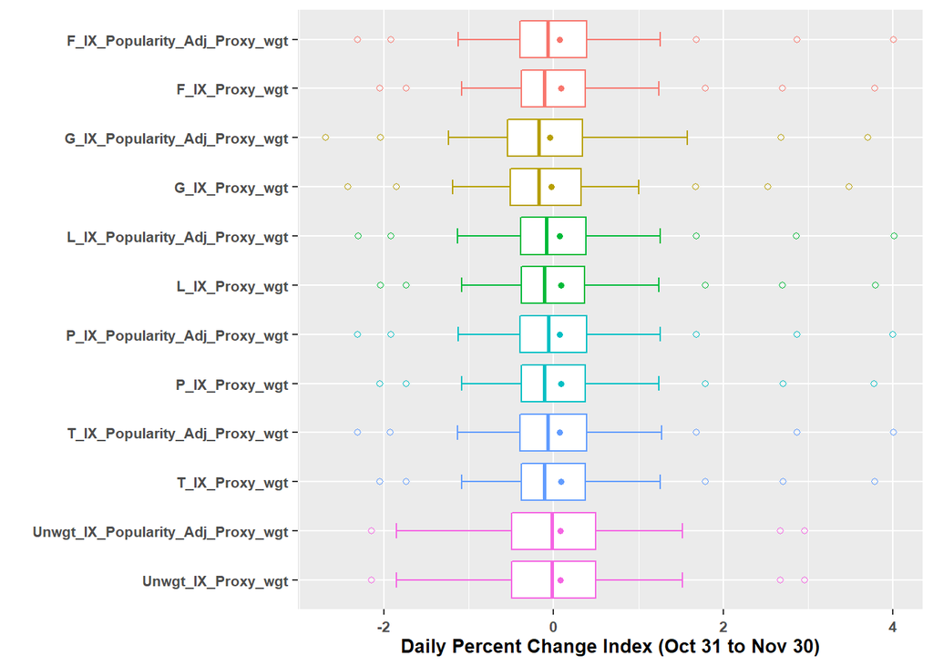

```r
####################
###   Boxplot    ###
####################

## Exclucing the Base index date 11-30 to calculate the summary stats
df0 <- data_index %>%
  filter(Date1 > "2019-10-30", Date1 <= "2019-11-30") %>%
  select(Date1, Day1, L_IX, P_IX, G_IX, F_IX, T_IX, Unwgt_IX, IX_type, n_matched)

### Long format ###
df0_long <- gather(df0, key=Index, value = Percent_Change, L_IX:Unwgt_IX) %>% mutate(IX_type_wgt = interaction(Index, IX_type, sep = "_"))

## Arrange dataset so boxplot is ordered specific way
df0_long2 <- df0_long %>%
  mutate(IX_type_wgt = interaction(Index, IX_type, sep = "_")) %>%
  arrange(desc(Index, IX_type))

## outline box colored
p <- ggplot(df0_long2, aes(x=factor(IX_type_wgt, levels=unique(IX_type_wgt)), y=Percent_Change, fill=IX_type_wgt)) + stat_boxplot(geom = "errorbar", width = 0.3, aes(color=Index)) +
  geom_boxplot(aes(fill=Index, color=Index), outlier.shape = 1, fill = "white") +
  stat_summary(fun.y=mean, geom="point", aes(colour=Index),size=1.3)

p + coord_flip() +
  theme(axis.title.x = element_text(face="bold", size=10),
        axis.title.y = element_text(face="bold", size=10),
        axis.text.x  = element_text(angle=0, vjust=0.5, size=8, face="bold"),
        axis.text.y  = element_text(hjust=1, size=8, face="bold"),
        legend.position = "none") +
  xlab("") + scale_y_continuous() +
  ylab("Daily Percent Change Index (Oct 31 to Nov 30)")
```

## Time Series Results: Autocorrelation and Seasonally Adjusted *Trend*

The *figures* below show the autocorrelation and partial-autocorrelation plots to assess whether increase or decrease in laptop price-change index is related to its past values; seasonal relationships in a week; and the decomposition plots to examine the *trend* after seasonality is extracted (adjusted). *Table 8* provides the results of statistical tests for Time Series index data.

```r
library(tseries)
df <- data_index %>%
  filter(Date1 > "2019-10-30", Date1 <= "2019-11-30", IX_type=="Proxy_wgt") %>%
  select(Date1, G_IX)

dt0 <- ts_ts(ts_long(df))
dt1 <- ts(dt0, frequency = 7)

###################################
#  Augemented Dickey-Fuller test ##
# Rejecting the null hypothesis
# suggests time series is stationary
##################################
a <- adf.test(dt1)
a2 <- cbind(a$method, round(a$p.value, 4), a$alternative)

#################################
####     Ljung-Box test      ####
# Large p value means white noice
################################
boxt <- Box.test(dt1, type="Ljung-Box")
a3 <- cbind(boxt$method, round(boxt$p.value, 4), ifelse(boxt$p.value>0.05, "white noise", "not white noise"))
a4 <- rbind(a2, a3)

as.tibble(a4) %>% rename(., "Table 8: Time Series Test"=V1, "p Value"=V2, "Result"=V3 )
```

| Table 8: Time Series Test | p Value | Result |
| --- | --- | --- |
| Augmented Dickey-Fuller Test | 0.0191 | stationary |
| Box-Ljung test | 0.1809 | white noise |

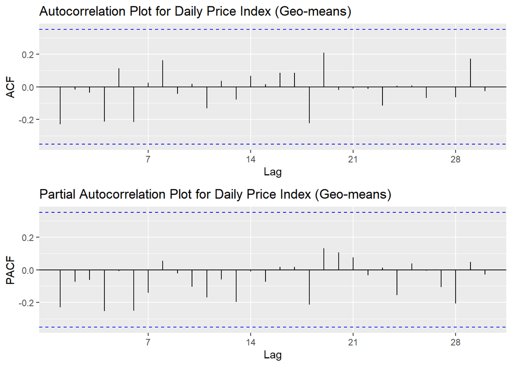

```r
library(cowplot)
library(gridExtra)
library(grid)

df <- data_index %>%
  filter(Date1 > "2019-10-30", Date1 <= "2019-11-30", IX_type=="Proxy_wgt") %>%
  select(Date1, G_IX)

dt0 <- ts_ts(ts_long(df))
dt1 <- ts(dt0, frequency = 7)

p1 <- ggAcf(dt1, lag=31) +
  ggtitle("Autocorrelation Plot for Daily Price Index (Geo-means)")

p2 <- ggPacf(dt1, lag=31) +
  ggtitle("Partial Autocorrelation Plot for Daily Price Index (Geo-means)")

grid.arrange(p1,p2, layout_matrix = rbind(c(1,1),c(2,2)))
```

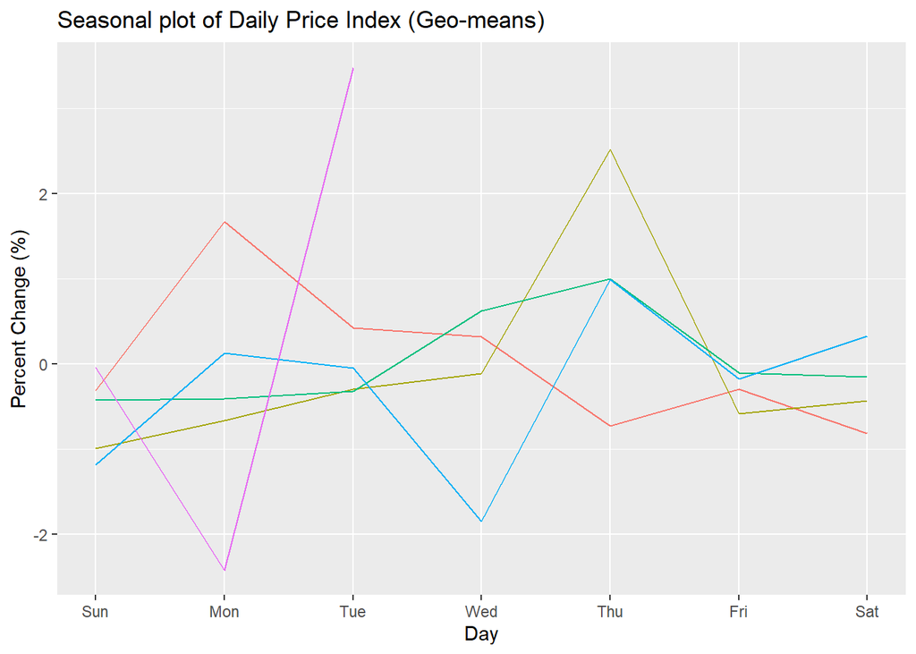

```r
ggseasonplot(dt1) +
  ylab("Percent Change (%)") +
  ggtitle("Seasonal plot of Daily Price Index (Geo-means)") +
  theme(legend.position = "none")
```

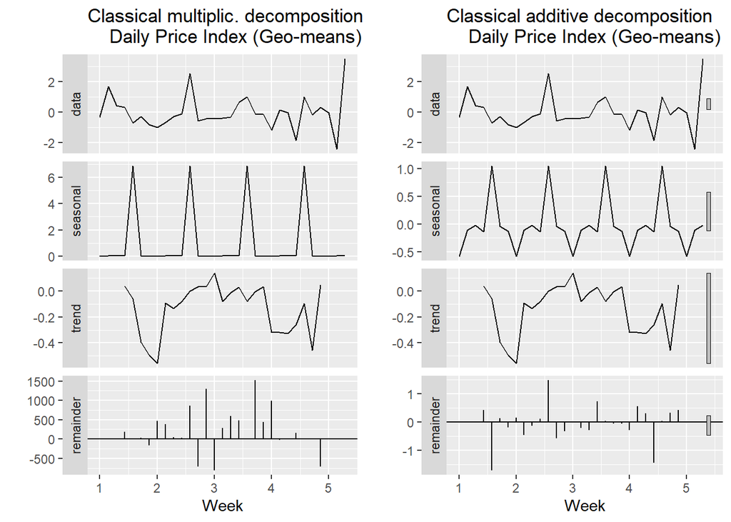

```r
######################################
###  Decomposition of Times series  ##
######################################

library(grid)

p1 <- dt1 %>% decompose(type="multiplicative") %>%
  autoplot() + xlab("Week") +
  ggtitle("Classical multiplic. decomposition
    Daily Price Index (Geo-means)")


p2 <- dt1 %>% decompose(type="additive") %>%
  autoplot() + xlab("Week") +
  ggtitle("Classical additive decomposition
    Daily Price Index (Geo-means)")

grid.arrange(p1, p2, nrow = 1)
```

# Final Deliverables: Shiny App, Daily Index & Regressions

A Shiny App is developed as the final deliverable of this study to visualize the daily laptop indexes to the users with interactive features and wide range of selection choices (https://hlpgomes.shinyapps.io/priceindex/).

# Conclusions and Benefits

**Amazon Price Change Index:** At minimum, this study develops a methodology and a pipeline to produce the daily percent change price index for Amazon products using web scrapping approach. Users of Amazon products could benefit from a daily price index.

**Data Visualization with Interactive Shiny App:** The daily index is displayed as a time series in real-time to the users, including multiple options, such as, weight selection, price formula selection, date range selection, comparing single or multiple time series simultaneously, and x, y axis magnifications.

**Trend Evaluation for Price Change:** The users have options to evaluate the trend of time series with 3 types of regression selections (Spline, LOESS, Linear), including choices for the degree of polynomial for Spline, smoothing parameter for LOESS, and color choice. The regression lines are auto adjusted as the date range is changed by a user. There is also an animation button where an user could select a date range and let the regressions move from date-to-date.

**Interactive D3.js Graph in R (dygraph):** The price change time series can be displays and shared as a HTML interactive graph to the stakeholders.

**BLS CPI vs. Web Scrapped Index:** 1-month percent change of Amazon Laptop and BLS EE01 indexes do not match. Potential reasons have been discussed for this difference in the *Discussions* section .

**Popular Items:** Exploratory analysis suggests, more popular laptops have slightly lower price change in average than less popular laptops; although there is no strong statistical evidence for this observation. Larger sample size is needed to re-evaluate in the future since the percent change numbers are very small in general but high variation.

**Autocorrelation:** No significant autocorrelation and partial-autocorrelation are observed in the series (no lag crosses the blue confidence band). It implies, no evidence to conclude that past value of index-change influences the current value of index-change. Furthermore, the large p-value of Ljung-Box Test implies the residuals of laptop index time series resemble white noise. *Therefore, the daily change in the laptop index is essentially a random amount uncorrelated with previous days* (within these date range). This may have to be re-evaluated in the future based on the larger sample size than n=31.

**Seasonality Adjusted Trend:** Decomposition method indicates a trend after adjusting for weekly seasonality effect of a specific day. This trend is not the trend of the data but after adjusting for the “day” effect. Box-Ljung Test indicates that the index series is a *white noise*. Combining both results it is concluded that *the trend is not predictable (stochastic) even after the adjustment of seasonal effect since the trend increases and decreases in an unpredictable manner throughout the month* (based on the decomposition plot). This may have to be re-evaluated with larger sample size.

# Discussions

Based on the Amazon data, the true 1-month Cost of Living Index (COLI) of laptop for Nov 2019 is between **-1.48% to -2.174%** (Nov 30 – Oct 30), or between **-1.287% to -1.541%** (Nov 26 – Oct 30) depending on the price formula used. On the other hand, 1-month percent change for BLS EE01 index is **0.077%** for Nov 2019 and **-2.434%** for Oct 2019.

*Why Amazon and BLS indexes do not match?* I had to wait until December 11, 2019 for the BLS *November* Index to be published before I could analyse and incorporate into this project. Hence, I did not have sufficient time to investigate the reasons behind this difference. Here are few reasons that could potentially explain this difference.

1. **Different collection date:** BLS has to collect all data by a certain time of the month in order to start the production and estimation tasks. Hence, it is unlikely that data from the end of the month would be incorporated. If I had an option, I would have computed index for Nov 15 – Oct 15 and then compare with BLS EE01 index. It is likely that BLS field office would start collecting data in the beginning and middle of the month, so that the production and estimation tasks could start before the end of the month. Some randomization method could be implemented if Amazon data is web scrapped every day. In that way, data would represent various days of a month.
2. **Mixed sample units in BLS EE01:** This Item Strata has sample units representing peripheral equipment including other types of personal computer. Amazon index is strictly based on Laptop items.
3. **BLS uses Final Sample Weight:** BLS uses population level weights that transforms each sampled price into a population level price change. Amazon index uses **proxy weight** based on the consumers review count. Many consumers may not write a review.

# Limitations

There are many limitations of this study.

**Representativeness and coverage:** Web scrapped data does not represent the population (consumers) who purchase outside the online domain or possibly other websites that display different price change patterns than Amazon.

**Quantity-sold information is *not* found:** How many of a specific item is sold (true quantities) is unknown for population level.

**Weighted, Proxy-Weighted (Pseudo), Unweighted Index:** BLS produces population level weight that represents 94% of the U.S. urban population. Hence CPI is a population level index. In this project, amazon customer’s review-count is used as a “sample weight” or proxy for amazon-sold-weight. It’s not the same as the BLS constructed population level weight. Unweighted is when quantity information is not used i.e., equal weight for each laptop (weight=1).

**List price does *not* imply what consumers paid:** List price does not necessarily reflect what consumers finally paid, including product tax and final sale price.

**Geography needed:** BLS collects data across various geography. Online prices may be the same regardless of a consumer’s geographic location.

**API is *no* longer provided:** Walmart and few other websites stopped APIs (discovered during market research process). Some 3rd party vendors provide product UPC and prices for purchase only. Therefore, incorporating web scrapped data into the production of official statistics run the risk for data not available.

**A unique item is *no* longer available:** One assumption of Price Theory is, price of a unique product is followed over time. BLS has analyst and methods in place to mitigate this issue, such as substitution with comparable item, hedonic modeling, imputation, etc.

**Matched sample:** If same unique item is not available, samples cannot to matched without additional work by analysts.

**Daily or weekly price index, *not* monthly:** Daily index is produced in this study due to time constraints of this project delivery. Generally monthly index shows “change” than daily index because many product-price do not change every day.

# Acknowledgement

Special thanks to Prof. Dr. Christoph Kern for teaching the graduate course SURV727 as a Visiting Assistant Professor at the University of Maryland, JPSM. Dr. Kern promoted independent research with data to demonstrate the skills and application in social science context. This motivated the author to conduct this original independent research work with web scrapped data. He recommended to incorporate popularity rating into the proxy-weight, hence the Popularity-Adjusted-Proxy-Weight is developed.

# Appendix

R Programs (.R) and data objects (.RData) are available at GitHub for reproducibility of this research. Here is the link https://github.com/hlpgomes/SURV727Project.

# References

Amazon, Web-Store. 2019. “Amazon Best Sellers in Laptop Computers.” *Amazon.com*. https://www.amazon.com/Best-Sellers-Electronics-Laptop-Computers/zgbs/electronics/565108/ref=zg_bs_pg_1?_encoding=UTF8&pg=1.

BLS, Chapter 17. 2018. “Chapter 17: The Consumer Price Index.” *BLS Handbook of Methods*. https://www.bls.gov/opub/hom/pdf/cpihom.pdf.

Dettling, M. 2015. *Applied Time Series Analysis*. Institute for Data Analysis and Process Design: Zurich.

Hyndman, R. J., and G. Athanasopoulos. 2018. *Forecasting: Principles and Practice*. OTexts: Melbourne, Australia. https://otexts.com/fpp2/.

ILO. 2004. *Consumer Price Index Manual: Theory and Practice*. International Labour Organization. https://www.ilo.org/.

Valliant, R., J. Dever, and K. Kreuter. 2013. *Practical Tools for Designing and Weighting Survey Samples*. Springer: New York.

Walmart, Open-API. 2019. “Walmart Open API Beta.” *Walmart.com*. https://developer.walmartlabs.com/.

Wickham, Hadley, and G. Grolemund. 2017. *R for Data Science*. O’Reilly.